# Manipulación de datos con dplyr

Noviembre, 2015

## Introducción

En el año 2014, Hadley Wickham junto a RStudio introducen un nuevo paquete llamado `dplyr` para facilitar el filtrado, la selección, la reestructuración y agregación de datos tabulares.

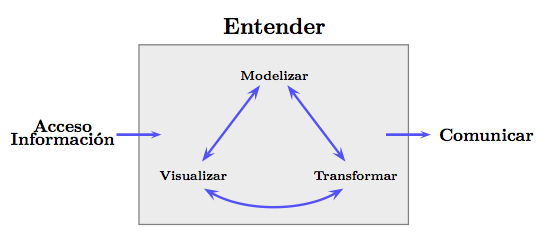

Objetivos principales:

- Proveer herramientas para la manipulación y análisis de datos.
- Mejorar el rendimiento en memoria implementando rutinas en C++.
- Usar una misma interfaz de trabajo sin importar donde se almacenan: `data.frame`, `data.table`, `database`.
- Introduce una gramática de manipulación de datos lo que permite encadenar operaciones bajo un nuevo operador `%>%`.

## Instalación y actualización

[figure not shown]

La descarga del paquete `dplyr` se realiza al igual que todos los paquetes de R desde el repositorio CRAN:

```r
install.packages('dplyr', dependencies = TRUE)
```

Sin embargo, existe una versión de desarrollo que puede obtenerse desde el repositorio Github:

```r
if (packageVersion("devtools") < 1.6) {
  install.packages("devtools", dependencies = TRUE)
}

devtools::install_github("hadley/lazyeval")
devtools::install_github("hadley/dplyr")
```

## Datos

Procedemos a cargar la data que se empleará a lo largo de la presentación:

```r
library(dplyr)

hflights <- tbl_df(read.csv("hflights.csv", stringsAsFactors = FALSE))
hflights
```

```
#> Source: local data frame [227,496 x 21]
#>
#>    Year Month DayofMonth DayOfWeek DepTime ArrTime UniqueCarrier FlightNum
#> 1  2011     1          1         6    1400    1500            AA       428
#> 2  2011     1          2         7    1401    1501            AA       428
#> 3  2011     1          3         1    1352    1502            AA       428
#> 4  2011     1          4         2    1403    1513            AA       428
#> 5  2011     1          5         3    1405    1507            AA       428
#> 6  2011     1          6         4    1359    1503            AA       428
#> 7  2011     1          7         5    1359    1509            AA       428
#> 8  2011     1          8         6    1355    1454            AA       428
#> 9  2011     1          9         7    1443    1554            AA       428
#> 10 2011     1         10         1    1443    1553            AA       428
#> ..  ...   ...        ...       ...     ...     ...           ...       ...
#> Variables not shown: TailNum (chr), ActualElapsedTime (int), AirTime
#>   (int), ArrDelay (int), DepDelay (int), Origin (chr), Dest (chr),
#>   Distance (int), TaxiIn (int), TaxiOut (int), Cancelled (int),
#>   CancellationCode (chr), Diverted (int)
```

## Diferencias entre tbl_df & dataframe

[figure not shown]

Con la finalidad de mejorar la velocidad en el procesamiento de datos, `dplyr` trae consigo una nueva estructura tabular denominada `tbl_df` (*tables dataframes*). Las principales diferencias respecto a los dataframes son:

- Cambia la forma de mostrar los datos sin alterar la estructura subyacente.
- Son estructuras entre 20X y 100X veces más rápidas realizando operaciones.
- Se elimina el uso repetitivo del objeto para acceder a sus columnas.
- Permite la utilización de un código más limpio junto al operador **magrittr** `%>%`

## El operador %>%

R es un lenguaje funcional, lo que significa que su código a menudo contiene una gran cantidad de paréntesis. Y mientras generamos código más complejo a menudo requerimos anidar sentencias usando demasiados paréntesis, lo que hace al código difícil de leer y entender.

```r
by(data[!is.na(data[,2]),], data[,4], summary)
```

### Paquete magrittr

El paquete **magrittr** ofrece un conjunto de operadores que promueven la semántica que mejore el código mediante la estructuración de las secuencias de operaciones de datos de izquierda a derecha (en lugar de desde el interior hacia fuera), evitando en lo posible las llamadas a funciones anidadas, minimizando la necesidad de variables locales y definición de funciones, por lo que resulta fácil agregar pasos en cualquier parte de la secuencia de las operaciones.

```r
data <- read_excel('/path/data/file.csv') %>%
      subset(var_1 > x) %>%
      transform(var_3 = var_2/var_1) %>%
      head(100)
```

## El operador %>%

Stefan Bache en el 2014 introdujo el operador `%>%` con la intención de volver más simple la escritura y la compresión de código en R.

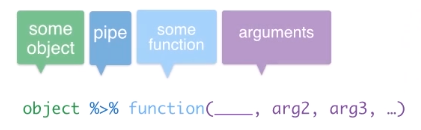

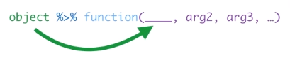

## Funcionamiento del operador magrittr %>%

### x %>% f es equivalente a f(x)

```r
iris %>% head
```

```
#>   Sepal.Length Sepal.Width Petal.Length Petal.Width Species
#> 1          5.1         3.5          1.4         0.2  setosa
#> 2          4.9         3.0          1.4         0.2  setosa
#> 3          4.7         3.2          1.3         0.2  setosa
#> 4          4.6         3.1          1.5         0.2  setosa
#> 5          5.0         3.6          1.4         0.2  setosa
#> 6          5.4         3.9          1.7         0.4  setosa
```

### x %>% f(y) es equivalente a f(x, y)

```r
iris %>% tail(5)
```

```
#>     Sepal.Length Sepal.Width Petal.Length Petal.Width   Species
#> 146          6.7         3.0          5.2         2.3 virginica
#> 147          6.3         2.5          5.0         1.9 virginica
#> 148          6.5         3.0          5.2         2.0 virginica
#> 149          6.2         3.4          5.4         2.3 virginica
#> 150          5.9         3.0          5.1         1.8 virginica
```

## Funcionamiento del operador magrittr %>%

### x %>% f %>% g es equivalente a g(f(x))

```r
iris %>% head(20) %>% summary()
```

```
#>   Sepal.Length    Sepal.Width    Petal.Length    Petal.Width
#>  Min.   :4.300   Min.   :2.90   Min.   :1.100   Min.   :0.100
#>  1st Qu.:4.775   1st Qu.:3.10   1st Qu.:1.400   1st Qu.:0.200
#>  Median :5.000   Median :3.45   Median :1.400   Median :0.200
#>  Mean   :5.035   Mean   :3.48   Mean   :1.435   Mean   :0.235
#>  3rd Qu.:5.400   3rd Qu.:3.80   3rd Qu.:1.500   3rd Qu.:0.300
#>  Max.   :5.800   Max.   :4.40   Max.   :1.700   Max.   :0.400
#>        Species
#>  setosa    :20
#>  versicolor: 0
#>  virginica : 0
#>
#>
#>
```

### x %>% f %>% g %>% h es equivalente a h(g(f(x)))

## Argumento marcador de posición

En ocasiones el argumento izquierdo del operador `%>%` no necesariamente coincide con el primer argumento de la función. Analicemos los siguientes casos:

### x %>% f(y, .) es equivalente a f(y, x)

```r
3L %>% head(iris,.)
```

```
#>   Sepal.Length Sepal.Width Petal.Length Petal.Width Species
#> 1          5.1         3.5          1.4         0.2  setosa
#> 2          4.9         3.0          1.4         0.2  setosa
#> 3          4.7         3.2          1.3         0.2  setosa
```

### x %>% f(y, z = .) es equivalente f(y, z = x)

```r
2L %>% summary(iris, digits=.)
```

```
#>   Sepal.Length  Sepal.Width   Petal.Length  Petal.Width        Species
#>  Min.   :4.3   Min.   :2.0   Min.   :1.0   Min.   :0.1   setosa    :50
#>  1st Qu.:5.1   1st Qu.:2.8   1st Qu.:1.6   1st Qu.:0.3   versicolor:50
#>  Median :5.8   Median :3.0   Median :4.3   Median :1.3   virginica :50
#>  Mean   :5.8   Mean   :3.1   Mean   :3.8   Mean   :1.2
#>  3rd Qu.:6.4   3rd Qu.:3.3   3rd Qu.:5.1   3rd Qu.:1.8
#>  Max.   :7.9   Max.   :4.4   Max.   :6.9   Max.   :2.5
```

## Reutilizando el marcador de posición

```r
iris %>%
  {
    n <- sample(1:10, size = 1)
    H <- head(., n)
    T <- tail(., n)
    rbind(H, T)
  } %>%
  summary()
```

```
#>   Sepal.Length    Sepal.Width     Petal.Length    Petal.Width
#>  Min.   :4.700   Min.   :3.000   Min.   :1.300   Min.   :0.200
#>  1st Qu.:4.950   1st Qu.:3.000   1st Qu.:1.400   1st Qu.:0.200
#>  Median :5.500   Median :3.100   Median :3.250   Median :1.000
#>  Mean   :5.550   Mean   :3.183   Mean   :3.300   Mean   :1.117
#>  3rd Qu.:6.125   3rd Qu.:3.350   3rd Qu.:5.175   3rd Qu.:1.950
#>  Max.   :6.500   Max.   :3.500   Max.   :5.400   Max.   :2.300
#>        Species
#>  setosa    :3
#>  versicolor:0
#>  virginica :3
#>
#>
#>
```

## Construcción de funciones

Cualquier enlace a partir de `.` devolverá una función que luego puede usarse para aplicar otros valores:

```r
f <- function(.) sin(cos(.))

f(0)
```

```
#> [1] 0.841471
```

```r
# es equivalente a
f <- . %>% cos %>% sin

f(0)
```

```
#> [1] 0.841471
```

Se recomienda el uso del operador `%>%` dentro de la creación de funciones sólo si el cuerpo de la función tiene una línea de código.

## Ejercicios

Los siguientes ejercicios pretenden mostrar las ventajas del operador magrittr:

```r
c(1, 2, 3, NA) %>% mean()
```

```
#> [1] NA
```

```r
c(1, 2, 3, NA) %>% mean(na.rm = TRUE)
```

```
#> [1] 2
```

```r
iris %>% mutate(dim=Sepal.Length*Sepal.Width) %>% filter(!is.na(dim)) %>% group_by(Species) %>%summarise(avg=mean(dim), sd=sd(dim))
```

```
#> Source: local data frame [3 x 3]
#>
#>      Species     avg       sd
#> 1     setosa 17.2578 2.933775
#> 2 versicolor 16.5262 2.866882
#> 3  virginica 19.6846 3.458783
```

## Los verbos de dplyr

El paquete `dplyr` cuenta con 5 funciones claves dentro de la manipulación de datos, también llamados *verbos*:

### select()

Devuelve un subconjunto de columnas.

Su estructura básica es:

```r
select(datos, var_1, var_2)
```

La forma equivalente mediante el uso del operador `%>%` es:

```r
datos %>% select(var_1, var_2)
```

dentro del `select` existen la posibilidad de usar el operador `:` para seleccionar una secuencia de columnas.

```r
# desde la variable 1 hasta la variable n
datos %>% select(var_1:var_n)
```

## select()

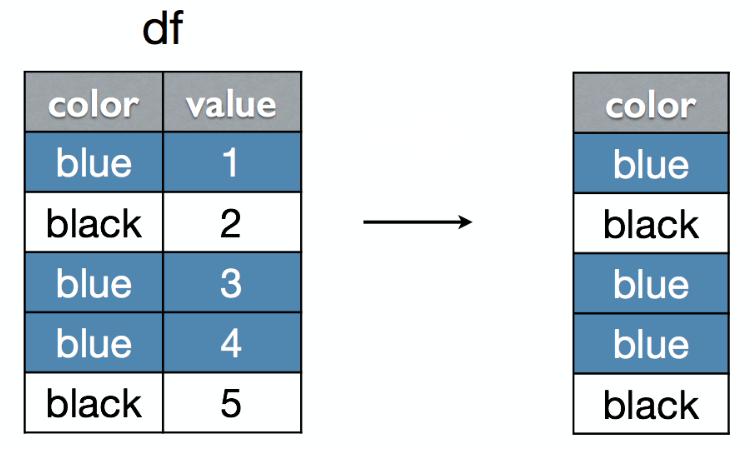

```r
select(df, color)
```

## select()

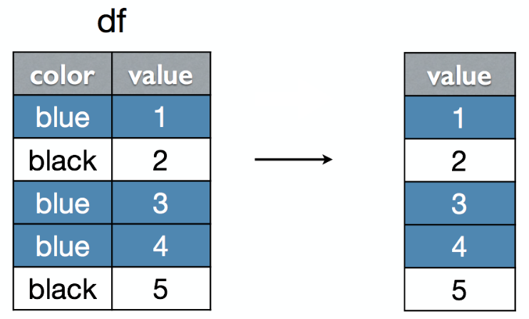

```r
select(df, -color)
```

## Opciones de selección entre columnas

La función `select` del paquete `dplyr` cuenta con *subfunciones especiales* que facilitan el trabajo con columnas:

- **starts_with:** Selecciona las variables que inicien con un cierto patrón.
- **end_with:** Selecciona las variables que finalizan con un cierto patrón.
- **contains:** Selecciona las variables que contienen un cierto patrón entre sus nombres.
- **matches:** Trabaja similar a **contains** con la diferencia que se emplea para expresiones regulares.
- **num_range:** Selecciona todas las variables en un rango.
- **one_of:** Selecciona las variables provistas por un vector de caracteres.
- **everything:** Selecciona todas las variables.

## Ejercicios

Genere un script para lo siguiente:

- Genere una copia de hflights que contengan las columnas entre `Origin` y `Cancelled`.
- Seleccione las variables desde hflights que terminen en `Delay` o `Time`.
- Seleccione las variables desde hflights que inicien con `Unique` o `Cancell`.
- Seleccione las variables que contengan `xi` entre sus nombres.
- Genere una copia de hflights sin la variables que inicien con `Ta`.
- Cree un copia de hflights retirando las variables que contengan la letra `y`.

## Los verbos de dplyr

El segundo de los verbos se encarga de la creación de nuevas variables.

### mutate()

Agrega columnas a una tabla existente.

Su estructura básica es:

```r
mutate(datos, new_var= var_1-var_2)
```

La forma equivalente mediante el uso del operador `%>%` es:

```r
datos %>% mutate(new_var=var_1-var_2)
```

Dentro de la creación de nuevas variables el usuario puede emplear operaciones entre columnas, o a su vez condicionales y funciones propias generadas.

## mutate()

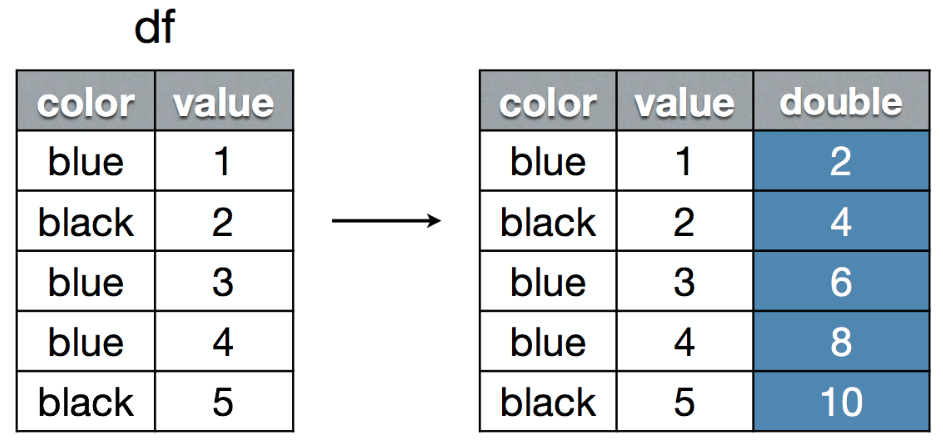

```r
mutate(df, double = 2 * value)
```

## mutate()

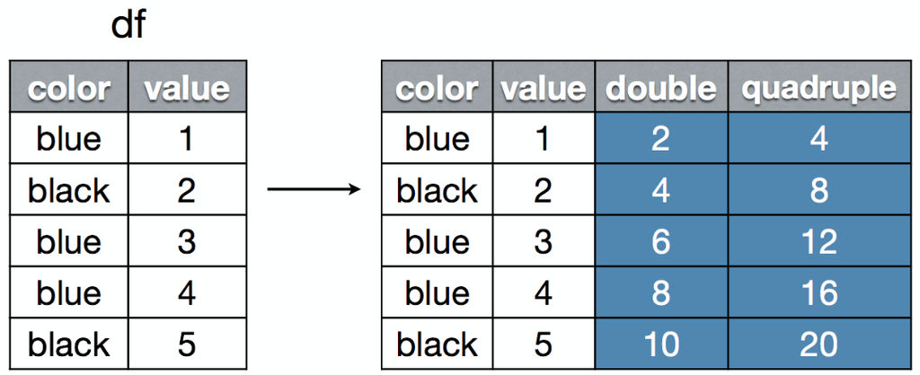

```r
mutate(df, double = 2 * value,  quadruple = 2 * double)
```

## Ejercicios

Genere un script para resolver lo siguiente:

- Agregar una nueva variable `ActualGroundTime` en la base hflights, misma que es obtenida de la diferencia entre `ActualElapsedTime` y `AirTime`.
- Generar la variable `GroundTime`a partir de la suma de `TaxiIn` & `TaxiOut`, almacenar la base como `df1`.
- Obtener la velocidad media de vuelo a empleando las variables `Distance` & `AirTime` (multiplicar por 60), almacenar el resultado con el nombre de `AverageSpeed` en una base de nombre `df2`.
- Generar la variable `loss_percent`, donde:

\[loss\_percent = loss\quad /\quad DepDelay * 100\] y \[loss = ArrDelay - DepDelay\]

## Los verbos de dplyr

El tercero de los verbos nos permite filtrar los registros (filas) de información.

### filter()

Devuelve un subconjunto de filas.

Su estructura básica es:

```r
filter(datos, condicion)
```

La forma equivalente mediante el uso del operador `%>%` es:

```r
datos %>% filter(condicion)
```

## filter()

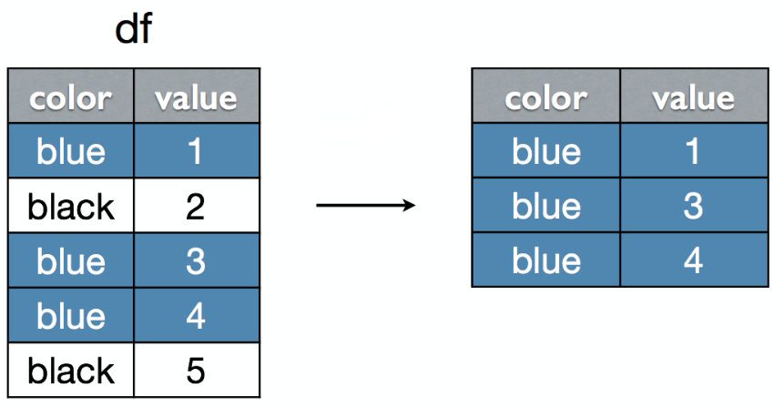

```r
filter(df, color == "blue")
```

## filter()

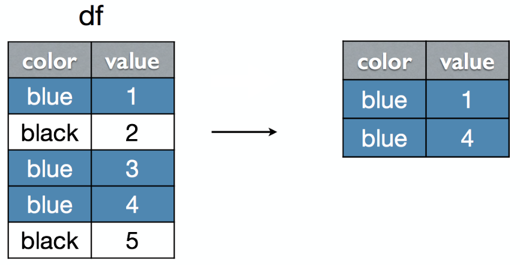

```r
filter(df, value %in% c(1, 4))
```

## filter()

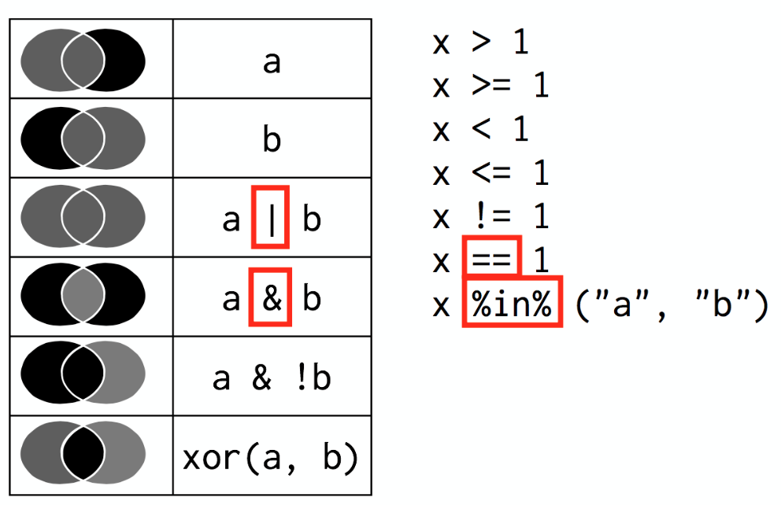

## Ejercicios

Genere un script para resolver lo siguiente:

- Filtre los vuelos para los cuales la variable `Distance` sea mayor o igual a 3000.
- Filtre los vuelos en la cual la variable `UniqueCarrier` tome los siguiente valores: "JetBlue", "Southwest", "Delta".
- Filtre los vuelos para los cuales la suma de las variables `TaxiIn` & `TaxiOut` supere a `AirTime`.
- Filtre los vuelos para `DepTime` inferiores a 500 o `ArrTime` superiores a 2200.

## Los verbos de dplyr

El cuarto verbo nos permite ordenar los registros (filas) de información en base a una o más variables.

### arrange()

Reordena las filas de acuerdo a variables simples o múltiples.

Su estructura básica es:

```r
arrange(datos, var_1, var_2,...)
```

La forma equivalente mediante el uso del operador `%>%` es:

```r
datos %>% arrange(var_1, var_2,...)
```

Se pueden ordenar datos considerando dos o más variables.

## arrange()

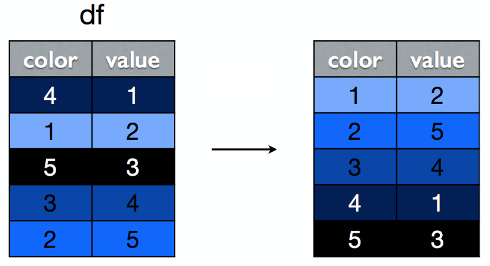

```r
arrange(df, color)
```

## arrange()

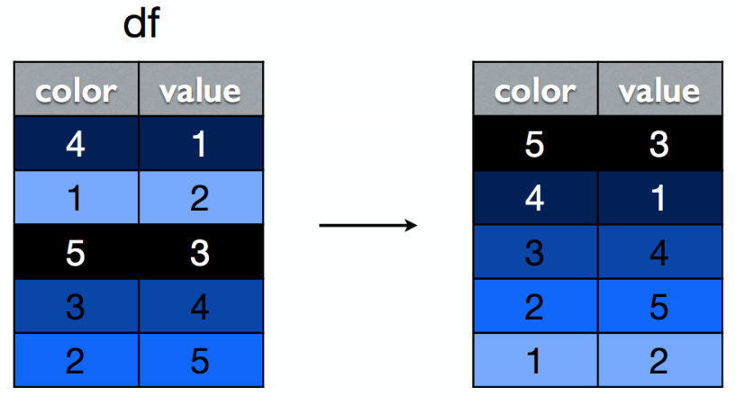

```r
arrange(df, desc(color))
```

## Ejercicios

Genere un script para resolver lo siguiente:

- Ordene la base hflights por la variable `DepDelay`.
- Ordene la base hflights por las variables `CancellationCode` & `UniqueCarrier` en el orden respectivo.
- Filtre los vuelos con `Dest` igual DFW, posteriormente ordene los resultados en forma descendente de acuerdo a `AirTime`.

## Los verbos de dplyr

El último de los verbos nos permite resumir la información a través del cálculo de estadísticos y más.

### summarise()

Realiza cálculos agregados por grupos.

A diferencia de los otros 4 verbos, `summarise` no retorna una copia de los datos en su lugar construye un nuevo conjunto que contiene el resumen estadístico.

Su sintaxis básica es:

```r
summarise(datos, sumvar = sum(A),  avgvar = avg(B), ...)
```

La forma equivalente mediante el uso del operador `%>%` es:

```r
datos %>% summarise(sumvar = sum(A),  avgvar = avg(B), ...)
```

## summarise()

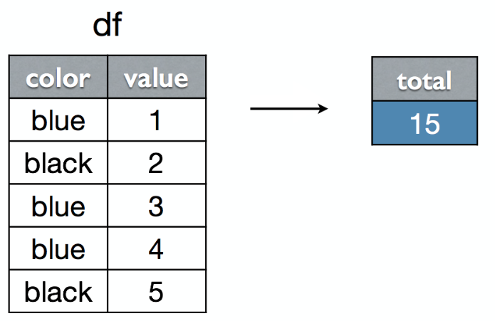

```r
summarise(df, total = sum(value))
```

## summarise()

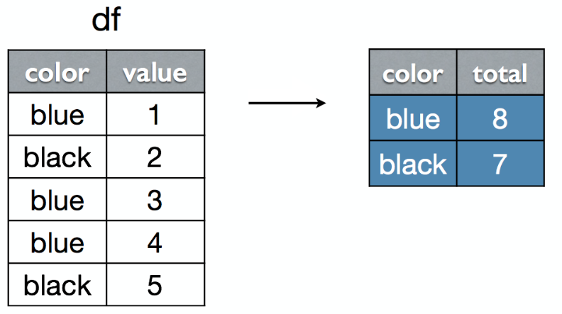

```r
by_color <- group_by(df, color)
summarise(by_color, total = sum(value))
```

## Ejercicios

Genere un script para resolver lo siguiente:

- Calcule las variable `min_dist` & `max_dist`, las mismas que son obtenidas como el mínimo y máximo de la variable `Distance`.
- Filtre los vuelos con la finalidad de eliminar los valores perdidos de `ArrDelay`, luego obtenga la media y desviación estándar de la variable antes mencionada.
- Obtenga el máximo de la diferencia en valor absoluto entre las variables `TaxiIn` & `TaxiOut`.

## Preguntas